# Images: Quantization and Sampling

This notebook extends the **Quantization and Sampling** lesson (https://makeabilitylab.github.io/physcomp/signals/QuantizationAndSampling/) from *audio* to *images*. Same two ideas, same Nyquist theorem, same aliasing -- just in 2D and with your eyes instead of your ears.

Recall: a digital signal differs from its continuous counterpart in two ways:

1. It is **sampled** at specific points. For audio, that's *time* (e.g. 44.1kHz). For images, a camera sensor samples a continuous 2D light field at specific *spatial* points -- the pixel grid. "Sampling rate" becomes "resolution" (pixels per image, or pixels per inch/cm).
2. It is **quantized** to specific levels. For audio, that's *voltage* (bit depth, e.g. 16-bit). For images, that's *brightness/color* -- a standard photo uses 8 bits per color channel (256 levels of red, green, blue).

| Audio (original notebook) | Images (this notebook) |
| --- | --- |
| Continuous voltage over time | Continuous light intensity over space |
| Sampling rate (Hz = samples/sec) | Resolution (pixels = samples/space) |
| Bit depth (amplitude levels) | Bit depth (brightness/color levels) |
| Nyquist: fs >= 2 * max frequency | Nyquist: sampling density >= 2 * max spatial frequency |
| Aliasing -> wrong pitch | Aliasing -> Moire patterns, jagged edges |
| Low-pass filter before ADC | Blur (optical/anti-alias filter) before downsampling |

We'll use fun, built-in sample images (no downloads needed) from `scikit-image`, plus a couple of synthetic "test patterns" (checkerboards, gratings) that make aliasing dramatically obvious -- the image equivalent of the audio notebook's pure sine-wave examples.

```python
import numpy as np
import matplotlib.pyplot as plt
from skimage import data, color, transform

import imagelab  # our small helper module (analogous to `from makelab import signal, audio`)

plt.rcParams["figure.dpi"] = 100
```

## Main image: our "Hello" for this notebook

In the audio lesson, everything revolved around a recording of someone saying "Hello." Here, our recurring example is a photo of a cat -- because who doesn't want to learn signal processing with cats.

```
--- cat_rgb (original) ---
  shape: (300, 451, 3)  dtype: uint8
  min: 0  max: 231  mean: 115.31
  resolution: 451 x 300 = 135,300 pixels
```

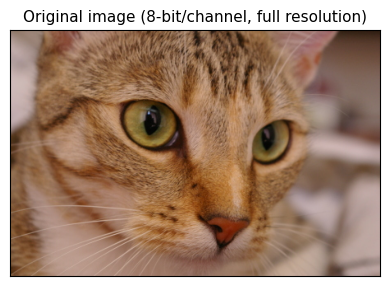

```
Each pixel stores 3 channels x 8 bits = 24 bits.
Number of possible colors per pixel: 16,777,216
```

```python
cat_rgb = data.chelsea()  # built-in scikit-image sample photo, uint8 RGB
imagelab.image_info(cat_rgb, "cat_rgb (original)")

fig, axes = imagelab.plot_image_grid([cat_rgb], ["Original image (8-bit/channel, full resolution)"])
plt.show()

print(f"Each pixel stores 3 channels x 8 bits = 24 bits.")
print(f"Number of possible colors per pixel: {256**3:,}")
```

# Part 1: Quantization

Quantization transforms a signal with a continuous (or very finely discretized) set of values into one with a much smaller, discrete set of values.

For images, instead of an ADC's voltage steps, we're reducing the number of brightness levels available per color channel. A standard photo uses 8 bits/channel (256 levels: 0-255). We'll shrink that down, just like the audio notebook shrank 16-bit audio down to 8, 6, 4, 3, and 2 bits.

Quantization step size (the image analog of the ADC's "5V / 2^10" step):

```python
for bits in [8, 4, 3, 2, 1]:
    levels = imagelab.num_quantization_levels(bits)
    step = imagelab.quantization_step_size(bits)
    print(f"{bits}-bit: {levels:>3} levels available, step size = {step:.2f} (out of 255)")
```

```
8-bit: 256 levels available, step size = 1.00 (out of 255)
4-bit:  16 levels available, step size = 17.00 (out of 255)
3-bit:   8 levels available, step size = 36.43 (out of 255)
2-bit:   4 levels available, step size = 85.00 (out of 255)
1-bit:   2 levels available, step size = 255.00 (out of 255)
```

## 4-bit quantization (16 levels per channel)

Still looks pretty close to the original -- similar to how 8-bit audio still sounded "pretty good."

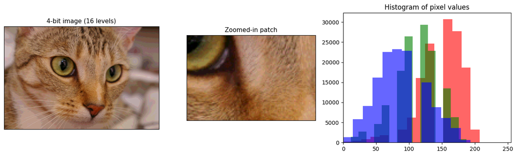

```python
fig, quantized_4bit = imagelab.plot_quantization_demo(cat_rgb, bits=4)
plt.show()
```

## 3-bit quantization (8 levels per channel)

Look closely at smooth gradients (like the cat's fur or the background blur) -- you should start to see faint "banding" or "contouring," where a smooth gradient breaks into visible discrete steps. This is the exact visual equivalent of hearing "steps" in the 6-bit audio waveform.

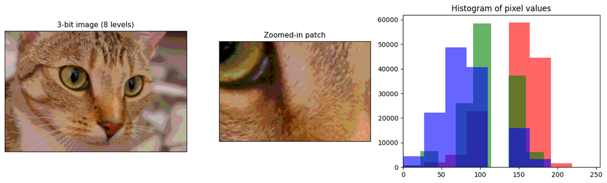

```python
fig, quantized_3bit = imagelab.plot_quantization_demo(cat_rgb, bits=3)
plt.show()
```

## 2-bit quantization (4 levels per channel)

Only 4 levels of red, green, and blue -- 4x4x4 = 64 possible colors total for the whole image! Strong banding/posterization is now obvious.

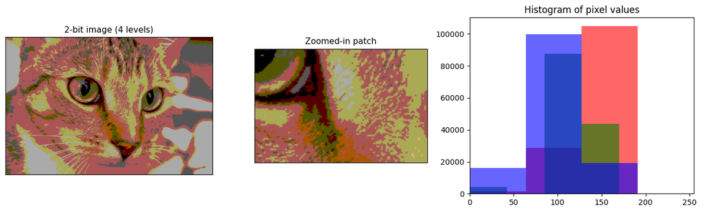

```python
fig, quantized_2bit = imagelab.plot_quantization_demo(cat_rgb, bits=2)
plt.show()
```

## 1-bit quantization (2 levels per channel = pure black/white per channel)

This is as extreme as the audio notebook's 2-bit audio example. The image is reduced to just 8 possible colors (2 levels x 3 channels), yet you can probably still tell it's a cat -- similar to how listeners could still make out "hello" in heavily-quantized audio.

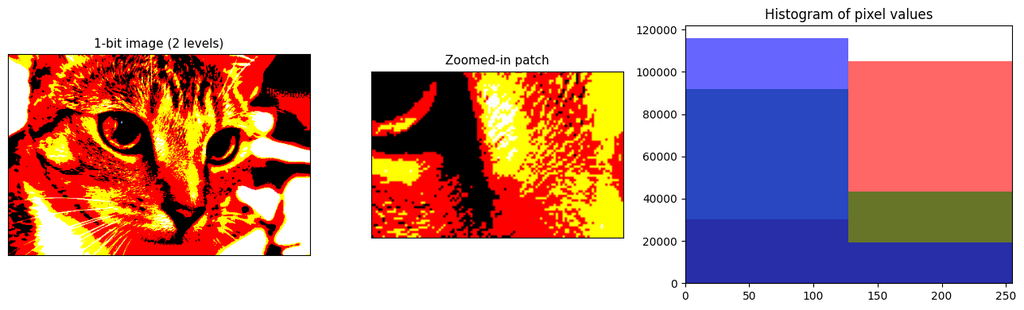

```python
fig, quantized_1bit = imagelab.plot_quantization_demo(cat_rgb, bits=1)
plt.show()
```

## Bonus/fun: Dithering -- cheating your way to better-looking low-bit images

Newspapers, old Macintosh screens, and 1-bit printers all faced the same problem: very few brightness levels available. Their trick was **dithering** -- spreading the *rounding error* from each pixel to its neighbors (Floyd-Steinberg error diffusion) so that, from a normal viewing distance, your eye averages the pattern of dots back into something that looks like more brightness levels than actually exist.

This is the spatial-domain cousin of tricks like noise-shaping in audio DACs. Let's compare plain 1-bit quantization to 1-bit *dithered* quantization on a grayscale version of our cat (dithering is easiest to see in grayscale, and is slow in pure Python, so we'll shrink the image a bit first).

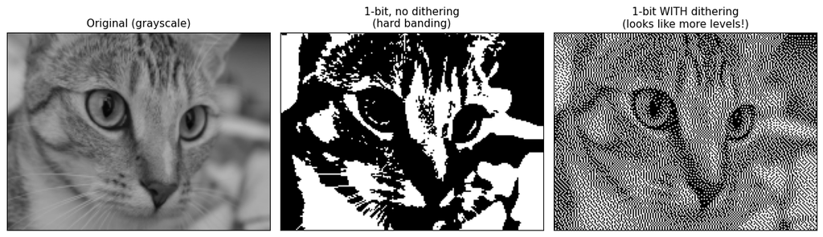

```python
cat_gray_small = color.rgb2gray(transform.resize(cat_rgb, (150, 200), anti_aliasing=True))
cat_gray_small = imagelab.to_uint8(cat_gray_small)

plain_1bit = imagelab.quantize_image(cat_gray_small, bits=1)
dithered_1bit = imagelab.floyd_steinberg_dither(cat_gray_small, bits=1)

fig, axes = imagelab.plot_image_grid(
    [cat_gray_small, plain_1bit, dithered_1bit],
    ["Original (grayscale)", "1-bit, no dithering\n(hard banding)", "1-bit WITH dithering\n(looks like more levels!)"],
)
plt.show()
```

## Exercise: play with your own image and quantization

Load any image of your own, and change `quantization_bits` below. At what bit depth do YOU start to notice banding? Does it differ between a photo with smooth gradients (like a sky) vs. one with lots of texture?

[figure not shown]

```python
your_image = data.astronaut()  # <-- swap this for your own image, e.g. via skimage.io.imread('your_photo.jpg')
quantization_bits = 3  # <-- change this and see what happens!

fig, _ = imagelab.plot_quantization_demo(your_image, bits=quantization_bits)
plt.show()
```

## Grayscale quantization: the same cat, at 8 / 6 / 4 / 2 / 1 bits

```
--- cat_gray (original, 8-bit grayscale) ---
  shape: (300, 451)  dtype: uint8
  min: 4  max: 194  mean: 119.48
  resolution: 451 x 300 = 135,300 pixels
```

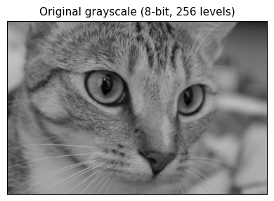

```python
cat_gray = imagelab.rgb_to_grayscale(cat_rgb)
imagelab.image_info(cat_gray, "cat_gray (original, 8-bit grayscale)")

fig, axes = imagelab.plot_image_grid([cat_gray], ["Original grayscale (8-bit, 256 levels)"])
plt.show()
```

### 8-bit grayscale (256 levels) -- our baseline, essentially "lossless" to the eye

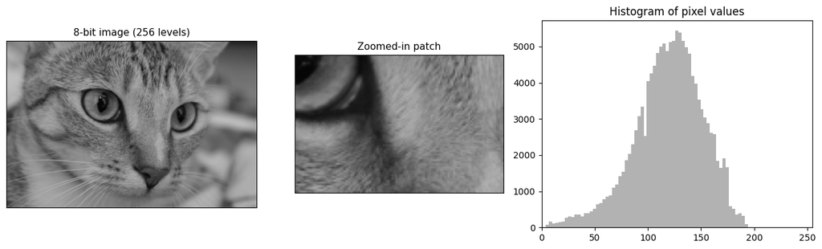

```python
fig, gray_8bit = imagelab.plot_quantization_demo(cat_gray, bits=8)
plt.show()
```

### 6-bit grayscale (64 levels)

Compare this to the audio notebook's 6-bit audio, where listeners first started to hear a faint hiss. Here, look for the first hint of banding in smooth areas like the out-of-focus background or the cat's cheek.

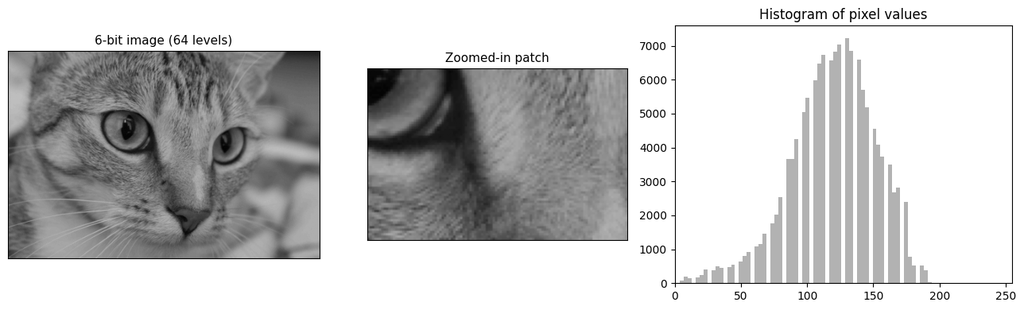

```python
fig, gray_6bit = imagelab.plot_quantization_demo(cat_gray, bits=6)
plt.show()
```

### 4-bit grayscale (16 levels)

Banding should now be clearly visible as faint "contour lines" in smoothly-shaded regions.

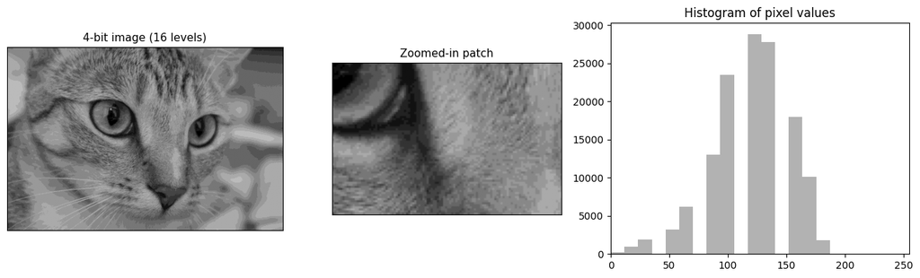

```python
fig, gray_4bit = imagelab.plot_quantization_demo(cat_gray, bits=4)
plt.show()
```

### 2-bit grayscale (4 levels)

Only 4 shades of gray for the *entire* image -- strong posterization, similar in spirit to the audio notebook's 2-bit audio example (only 4 amplitude levels).

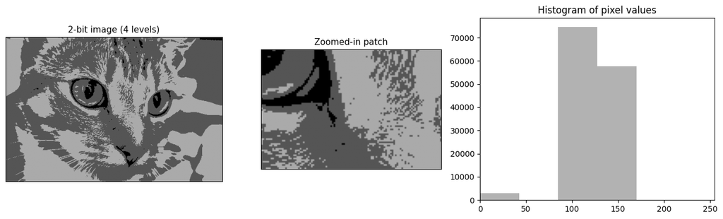

```python
fig, gray_2bit = imagelab.plot_quantization_demo(cat_gray, bits=2)
plt.show()
```

### 1-bit grayscale (2 levels = pure black & white)

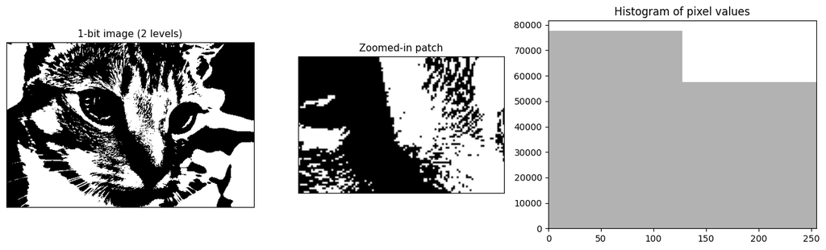

```python
fig, gray_1bit = imagelab.plot_quantization_demo(cat_gray, bits=1)
plt.show()
```

### Side-by-side: all five grayscale bit depths at once

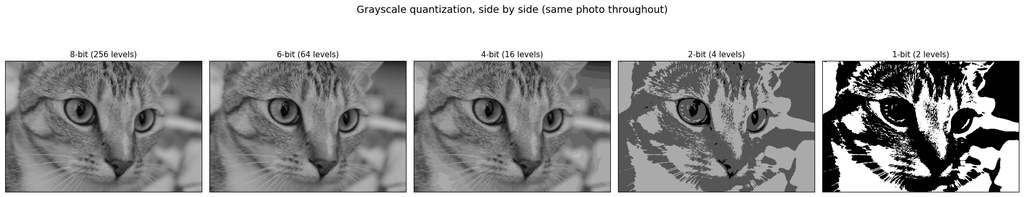

```python
fig, axes = imagelab.plot_image_grid(
    [cat_gray, gray_6bit, gray_4bit, gray_2bit, gray_1bit],
    ["8-bit (256 levels)", "6-bit (64 levels)", "4-bit (16 levels)", "2-bit (4 levels)", "1-bit (2 levels)"],
    suptitle="Grayscale quantization, side by side (same photo throughout)",
    ncols=5,
)
plt.show()

#
# The other half of digitization is **sampling rate** -- how densely we
# capture the signal. For images, "sampling rate" = resolution: how many
# pixels per unit of physical space (or, simply, pixels per image).
#
# Just like undersampling audio in time throws away high temporal
# frequencies (and can cause aliasing), undersampling an image in space
# throws away fine detail (high spatial frequencies) and can cause its
# own kind of aliasing: **Moire patterns** and jagged/false textures.
```

## Naive downsampling: just skip pixels

Just like the audio notebook downsamples with `audio_data[::factor]`, we can naively downsample an image with `img[::factor, ::factor]`. We then blow the result back up (nearest-neighbor) just so we can compare it to the original at the same physical size.

```
Downsample x2: 451x300 -> 226x150 pixels (33,900 vs 135,300 total pixels)
```

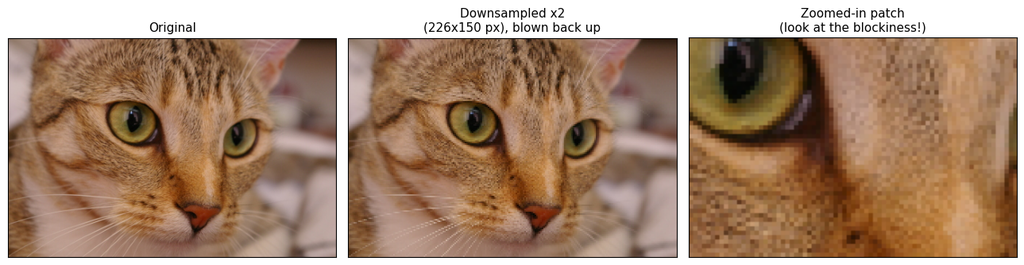

```
Downsample x4: 451x300 -> 113x75 pixels (8,475 vs 135,300 total pixels)
```

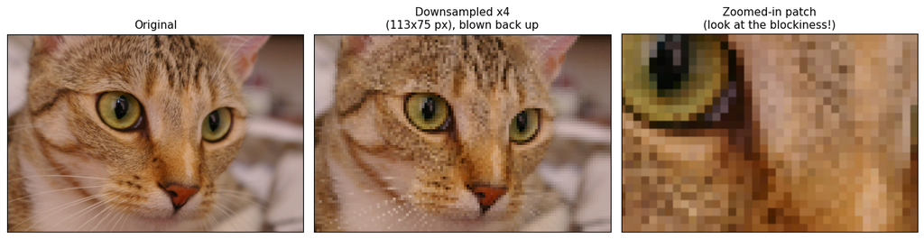

```
Downsample x8: 451x300 -> 57x38 pixels (2,166 vs 135,300 total pixels)
```

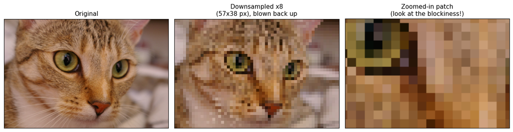

```
Downsample x16: 451x300 -> 29x19 pixels (551 vs 135,300 total pixels)
```

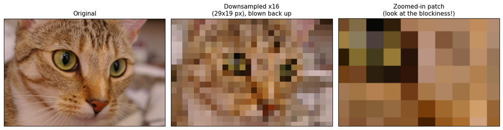

```python
for factor in [2, 4, 8, 16]:
    fig, down = imagelab.plot_sampling_demo(cat_rgb, factor)
    h, w = cat_rgb.shape[:2]
    print(f"Downsample x{factor}: {w}x{h} -> {down.shape[1]}x{down.shape[0]} pixels "
          f"({down.shape[0]*down.shape[1]:,} vs {h*w:,} total pixels)")
    plt.show()
```

Notice how, just like low-sample-rate audio lost its clarity but you could still make out "hello" at surprisingly low sampling rates, you can probably still tell "that's a cat" even at x16 downsampling -- but fine detail (whiskers! fur texture!) is completely gone.

## The Nyquist Sampling Theorem, for images

Same theorem as before, just in space instead of time:

> A signal can be perfectly reconstructed only if it was sampled at a rate at least **twice** its highest frequency component.

For audio: $f_s \geq 2 \times f_{max}$ (samples/second vs. Hz).

For images: **sampling density** (pixels per unit length) must be at least twice the highest **spatial frequency** (cycles per unit length) present in the scene. A spatial frequency is just "how many light-dark-light-dark cycles per unit distance" -- e.g., the stripes on a shirt, a picket fence, window blinds, or fine fabric weave.

If your camera's pixel density can't keep up with a fine repeating pattern (like a person wearing a finely striped shirt on TV), you get **aliasing**: the fine pattern "impersonates" a completely different, coarser, often swirling pattern -- the Moire effect.

## Aliasing demo #1: sinusoidal gratings (the image version of pure tones)

Just like the audio notebook sampled pure sine tones (5Hz, 10Hz, 20Hz, 60Hz) at a fixed 50Hz rate to show aliasing, let's create pure spatial "tones" -- sinusoidal gratings -- at different spatial frequencies, and sample them all at the same rate.

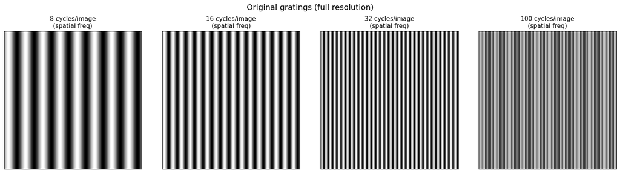

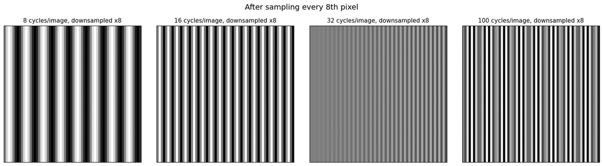

```
With a sampling factor of 8 (i.e., 64 samples across the image),
the Nyquist limit is 32 cycles/image.
Gratings with more cycles than that will alias into a LOWER, fake frequency (or moire bands)!
```

```python
grating_sizes = [512, 512, 512, 512]
cycles_list = [8, 16, 32, 100]  # spatial frequency: cycles across the image width
sample_factor = 8               # our fixed "sampling rate" (keep every 1/8th pixel)

gratings = [imagelab.create_sinusoidal_grating(size=512, cycles=c) for c in cycles_list]
titles = [f"{c} cycles/image\n(spatial freq)" for c in cycles_list]
fig, axes = imagelab.plot_image_grid(gratings, titles, suptitle="Original gratings (full resolution)")
plt.show()

sampled = [imagelab.upsample_nearest(imagelab.downsample_image(g, sample_factor), sample_factor)[:512, :512]
           for g in gratings]
fig, axes = imagelab.plot_image_grid(sampled, [f"{c} cycles/image, downsampled x{sample_factor}" for c in cycles_list],
                                      suptitle=f"After sampling every {sample_factor}th pixel")
plt.show()

nyquist_cycles = (512 / sample_factor) / 2
print(f"With a sampling factor of {sample_factor} (i.e., {512//sample_factor} samples across the image),")
print(f"the Nyquist limit is {nyquist_cycles:.0f} cycles/image.")
print("Gratings with more cycles than that will alias into a LOWER, fake frequency (or moire bands)!")
```

## Aliasing formula, translated from audio to images

Recall the audio notebook's aliasing formula: $$ f_{aliased} = |\,round(f / f_s) \cdot f_s - f\,| $$

The exact same formula applies to spatial frequencies. Let's compute it for our gratings above (using "samples across the image" as our spatial $f_s$):

```python
fs_spatial = 512 / sample_factor  # samples across the image width = our spatial sampling rate
for c in cycles_list:
    aliased = imagelab.aliased_spatial_freq(c, fs_spatial)
    tag = "  <-- aliased! (looks like a different, coarser pattern)" if c > fs_spatial / 2 else ""
    print(f"{c:>3} cycles/image, sampled at {fs_spatial:.0f} samples/image -> "
          f"appears as {aliased:.1f} cycles/image{tag}")
```

```
  8 cycles/image, sampled at 64 samples/image -> appears as 8.0 cycles/image
 16 cycles/image, sampled at 64 samples/image -> appears as 16.0 cycles/image
 32 cycles/image, sampled at 64 samples/image -> appears as 32.0 cycles/image
100 cycles/image, sampled at 64 samples/image -> appears as 28.0 cycles/image  <-- aliased! (looks like a different, coarser pattern)
```

Just like the audio notebook plotted the aliasing "triangle wave" (real frequency vs. apparent/sampled frequency), let's do the same for spatial frequencies:

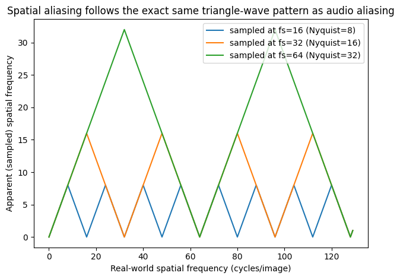

```python
real_freqs = np.arange(0, 130, 1)
for fs in [16, 32, 64]:
    apparent = [imagelab.aliased_spatial_freq(f, fs) for f in real_freqs]
    plt.plot(real_freqs, apparent, label=f"sampled at fs={fs} (Nyquist={fs/2:.0f})")
plt.xlabel("Real-world spatial frequency (cycles/image)")
plt.ylabel("Apparent (sampled) spatial frequency")
plt.title("Spatial aliasing follows the exact same triangle-wave pattern as audio aliasing")
plt.legend()
plt.tight_layout()
plt.show()
```

## Aliasing demo #2: the zone plate (the image version of a frequency sweep)

The audio notebook used a 0-22,050Hz frequency *sweep* to show aliasing "turning on" as frequency increased. The 2D image equivalent is a **zone plate**: a pattern whose spatial frequency increases smoothly with distance from the center. At full resolution it's a clean set of rings. Once we undersample it, the outer (high-frequency) rings alias into swirly Moire patterns while the inner (low-frequency) rings stay clean.

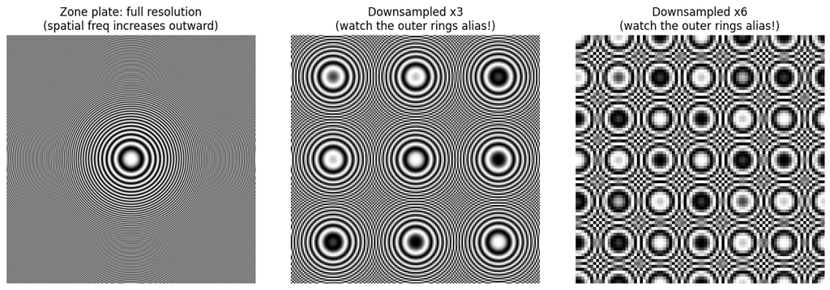

```python
zone_plate = imagelab.create_zone_plate(size=512, k=0.5)

fig, axes = plt.subplots(1, 3, figsize=(13, 4.3))
axes[0].imshow(zone_plate, cmap="gray")
axes[0].set_title("Zone plate: full resolution\n(spatial freq increases outward)")
axes[0].axis("off")

for ax, factor in zip(axes[1:], [3, 6]):
    down = imagelab.downsample_image(zone_plate, factor)
    up = imagelab.upsample_nearest(down, factor)[:512, :512]
    ax.imshow(up, cmap="gray")
    ax.set_title(f"Downsampled x{factor}\n(watch the outer rings alias!)")
    ax.axis("off")
fig.tight_layout()
plt.show()
```

You don't need a synthetic pattern to see aliasing "in the wild." Fine, repeating real-world textures (brick walls, roof tiles, window screens, striped/checked fabric) alias too. Here's a checkerboard test pattern, naively downsampled:

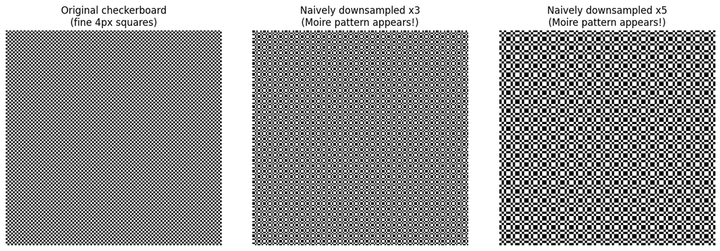

```python
checker = imagelab.create_checkerboard(size=480, square_size=4)

fig, axes = plt.subplots(1, 3, figsize=(13, 4.3))
axes[0].imshow(checker, cmap="gray")
axes[0].set_title("Original checkerboard\n(fine 4px squares)")
axes[0].axis("off")

for ax, factor in zip(axes[1:], [3, 5]):
    down = imagelab.downsample_image(checker, factor)
    up = imagelab.upsample_nearest(down, factor)[:480, :480]
    ax.imshow(up, cmap="gray")
    ax.set_title(f"Naively downsampled x{factor}\n(Moire pattern appears!)")
    ax.axis("off")
fig.tight_layout()
plt.show()
```

## Fixing aliasing: low-pass filter (blur) BEFORE you downsample

The audio notebook hinted at this in its TODO list: "possibly talk about using a low-pass filter before downsampling?" For images, the fix is the same idea as an anti-aliasing filter on an ADC: **blur the image first** (removing high spatial frequencies) before throwing away pixels. This is exactly what camera sensors do optically (an anti-aliasing/optical low-pass filter) and what good image-resizing algorithms do mathematically.

Let's compare naive downsampling vs. blur-then-downsample on the checkerboard:

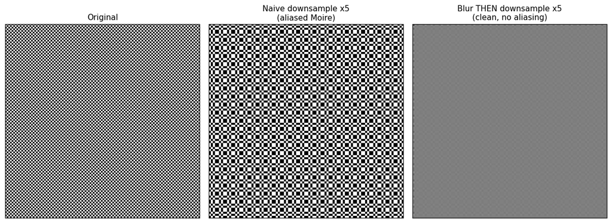

```
This is exactly why professional image/video resizing tools (and camera sensors)
apply a blur/anti-aliasing filter before reducing resolution -- it trades a little
sharpness for avoiding the much worse Moire artifacts of naive sampling.

Notice the 'fixed' version came out almost perfectly FLAT GRAY, not a smaller
checkerboard. That's actually the mathematically correct answer, not a bug! The
checker pattern's frequency is simply too high to be represented at all once we've
downsampled x5 -- so a proper low-pass filter correctly throws that information
away (leaving the average brightness) instead of aliasing it into a FAKE lower-
frequency pattern. 'Clean' doesn't always mean 'detailed' -- sometimes the honest
answer to 'what does this look like at low resolution' is simply 'you can't tell.'
```

```python
factor = 5
naive = imagelab.upsample_nearest(imagelab.downsample_image(checker, factor), factor)[:480, :480]
blurred_first = imagelab.lowpass_blur(checker, sigma=factor / 2)
filtered = imagelab.upsample_nearest(imagelab.downsample_image(blurred_first, factor), factor)[:480, :480]

fig, axes = imagelab.plot_image_grid(
    [checker, naive, filtered],
    ["Original", f"Naive downsample x{factor}\n(aliased Moire)", f"Blur THEN downsample x{factor}\n(clean, no aliasing)"],
)
plt.show()

print("This is exactly why professional image/video resizing tools (and camera sensors)")
print("apply a blur/anti-aliasing filter before reducing resolution -- it trades a little")
print("sharpness for avoiding the much worse Moire artifacts of naive sampling.")
print()
print("Notice the 'fixed' version came out almost perfectly FLAT GRAY, not a smaller")
print("checkerboard. That's actually the mathematically correct answer, not a bug! The")
print("checker pattern's frequency is simply too high to be represented at all once we've")
print("downsampled x5 -- so a proper low-pass filter correctly throws that information")
print("away (leaving the average brightness) instead of aliasing it into a FAKE lower-")
print("frequency pattern. 'Clean' doesn't always mean 'detailed' -- sometimes the honest")
print("answer to 'what does this look like at low resolution' is simply 'you can't tell.'")
```

## Real-world Nyquist demo: sampling above vs. below Nyquist on an actual photo

The zone plate and checkerboard above are *synthetic* test patterns -- useful because they have one clean, known frequency (or a smooth sweep of frequencies). But how does this play out on an actual photograph?

Let's use a real, public-domain photo of a brick sidewalk (bundled with `scikit-image`, no download needed) -- a great real-world example because it has an obvious, fairly regular repeating structure (the brick joints), so it behaves a bit like the checkerboard, but with all the messiness of a real photo (varying lighting, perspective, some irregularity in the bricks).

We'll:

1. Automatically estimate the photo's **dominant spatial frequency** using an FFT (the image equivalent of looking at an audio signal's frequency spectrum to find its pitch).
2. Compute the **Nyquist-safe sampling rate** implied by that frequency.
3. Downsample the photo once at a factor that stays *above* the Nyquist rate, and once at a factor that drops *below* it -- then compare.

```
--- brick_photo ---
  shape: (512, 512)  dtype: uint8
  min: 63  max: 207  mean: 111.46
  resolution: 512 x 512 = 262,144 pixels
```

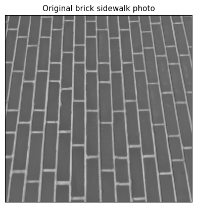

```python
brick_photo = data.brick()  # a real, public-domain photo (scikit-image sample data)
imagelab.image_info(brick_photo, "brick_photo")

fig, axes = imagelab.plot_image_grid([brick_photo], ["Original brick sidewalk photo"])
plt.show()
```

```python
freq_info = imagelab.estimate_dominant_spatial_frequency(brick_photo, axis=0)
print(f"Image width: {freq_info['length']} px")
print(f"Estimated dominant spatial frequency: {freq_info['cycles_per_image']:.1f} cycles/image "
      f"(i.e., a repeating pattern every ~{freq_info['period_px']:.1f} px -- the spacing between brick joints)")

nyquist_safe_factor = imagelab.nyquist_safe_max_factor(freq_info["cycles_per_image"], freq_info["length"])
print(f"\nTo satisfy Nyquist (sampling rate >= 2 x dominant frequency), we can downsample by AT MOST "
      f"x{nyquist_safe_factor} and still safely capture this pattern.")

safe_factor = max(1, nyquist_safe_factor // 2)     # comfortably ABOVE the Nyquist rate
aliased_factor = nyquist_safe_factor * 2           # well BELOW the Nyquist rate

print(f"\n--> We'll compare downsampling x{safe_factor} (safely above Nyquist) "
      f"vs. x{aliased_factor} (well below Nyquist).")
```

```
Image width: 512 px
Estimated dominant spatial frequency: 13.0 cycles/image (i.e., a repeating pattern every ~39.4 px -- the spacing between brick joints)

To satisfy Nyquist (sampling rate >= 2 x dominant frequency), we can downsample by AT MOST x19 and still safely capture this pattern.

--> We'll compare downsampling x9 (safely above Nyquist) vs. x38 (well below Nyquist).
```

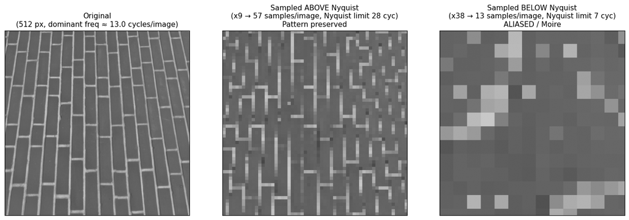

```python
fig, down_safe, down_aliased = imagelab.plot_nyquist_comparison(
    brick_photo, safe_factor=safe_factor, aliased_factor=aliased_factor, dominant_info=freq_info
)
plt.show()
```

A couple of things worth pointing out to students here:

- The **"above Nyquist"** version still clearly shows individual brick joints -- resolution was thrown away, but the *pattern* survived, exactly as Nyquist's theorem predicts.
- The **"below Nyquist"** version has lost the brick pattern entirely -- notice it does NOT simply look like a smaller/blurrier version of the bricks. Information has been scrambled into something that no longer represents the real structure.
- Unlike our clean synthetic sine-wave grating (which aliased into one other clean, predictable frequency), this REAL photo's aliasing looks more like disorganized blotches/noise rather than a tidy substitute pattern. That's because a real photo isn't a single pure spatial frequency -- it's a mix of many frequencies and orientations at once (the diagonal brick-laying pattern, lighting gradients, mortar texture...), and undersampling scrambles *all* of them together. This is exactly why real-world Moire (on striped shirts, screens photographed by other screens, fences, roof tiles) can look messy and unpredictable rather than a neat "false pattern" -- the clean textbook examples (pure tones, checkerboards) are the *easy* case!

## Exercise: experiment with your own image and sampling factor

Try your own photo (ideally one with fine texture -- brick, fabric, grass, hair) and different `sampling_factor` values. Do you see Moire patterns with naive downsampling? Does blurring first fix it?

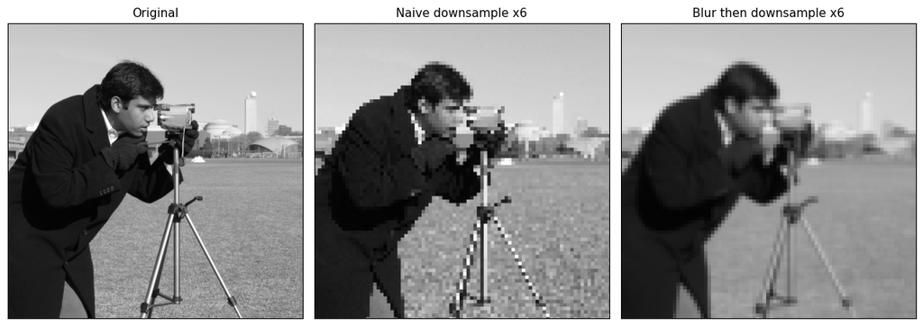

```python
your_image_2 = data.camera()  # <-- swap this for your own image
sampling_factor = 6  # <-- change this and see what happens!

naive_2 = imagelab.upsample_nearest(imagelab.downsample_image(your_image_2, sampling_factor), sampling_factor)
blurred_2 = imagelab.lowpass_blur(your_image_2, sigma=sampling_factor / 2)
filtered_2 = imagelab.upsample_nearest(imagelab.downsample_image(blurred_2, sampling_factor), sampling_factor)

h, w = your_image_2.shape[:2]
fig, axes = imagelab.plot_image_grid(
    [your_image_2, naive_2[:h, :w], filtered_2[:h, :w]],
    ["Original", f"Naive downsample x{sampling_factor}", f"Blur then downsample x{sampling_factor}"],
)
plt.show()
```

## Discussion questions for class

1. In quantization, why did banding show up first in smooth gradients (sky, skin, fur) rather than in high-detail/textured areas?
2. In sampling, why does the *checkerboard* alias so much more dramatically than a smoothly-varying image like a sunset?
3. Your phone camera has an "anti-aliasing filter" (or relies on pixel density being high enough that it usually doesn't matter). Can you find a real photo online with visible Moire (hint: search "moire pattern photo shirt" or "moire pattern screen photo")? Why do screens photographed by other screens/cameras alias so often?
4. JPEG compression is a *different* kind of lossy transformation than quantization or sampling -- can you predict, before trying it, at what quality level you'd start to see visible artifacts, and would they look more like banding or more like Moire?
5. Audio CDs use 16-bit/44.1kHz. Standard photos use 8-bit/channel. Why do you think images "get away with" fewer quantization levels than audio, relative to what our senses can perceive?